# Lab #10

Ifeoma Okonye

2024-04-17

## Introduction

To begin, I imported the required datalayers. The layers were riley county groundwater well points and the riley county boundry. I then did some tidying and made sure all data layers were in the right coordinate reference system.

```r
library(pacman)
p_load(sf, spdep, tidyverse, spatstat, tigris, terra, raster, RColorBrewer)


r_county <- counties() %>%
  filter(STATEFP == 20, COUNTYFP == 161) %>% shift_geometry() #Riley county is STATEFP: 20, COUNTYFP: 161
r_county
```

```
## Simple feature collection with 1 feature and 17 fields
## Geometry type: MULTIPOLYGON
## Dimension:     XY
## Bounding box:  xmin: -82264.05 ymin: 173040.5 xmax: -33301.15 ymax: 232018.6
## Projected CRS: USA_Contiguous_Albers_Equal_Area_Conic
##   STATEFP COUNTYFP COUNTYNS GEOID  NAME     NAMELSAD LSAD CLASSFP MTFCC CSAFP
## 1      20      161 00485044 20161 Riley Riley County   06      H1 G4020  <NA>
##   CBSAFP METDIVFP FUNCSTAT      ALAND   AWATER    INTPTLAT     INTPTLON
## 1   <NA>     <NA>        A 1579010807 32092080 +39.2912101 -096.7274879
##                         geometry
## 1 MULTIPOLYGON (((-47405.58 1...
```

```r
st_crs(r_county)
```

```
## Coordinate Reference System:
##   User input: ESRI:102003
##   wkt:
## PROJCRS["USA_Contiguous_Albers_Equal_Area_Conic",
##     BASEGEOGCRS["NAD83",
##         DATUM["North American Datum 1983",
##             ELLIPSOID["GRS 1980",6378137,298.257222101,
##                 LENGTHUNIT["metre",1]]],
##         PRIMEM["Greenwich",0,
##             ANGLEUNIT["degree",0.0174532925199433]],
##         ID["EPSG",4269]],
##     CONVERSION["USA_Contiguous_Albers_Equal_Area_Conic",
##         METHOD["Albers Equal Area",
##             ID["EPSG",9822]],
##         PARAMETER["Latitude of false origin",37.5,
##             ANGLEUNIT["degree",0.0174532925199433],
##             ID["EPSG",8821]],
##         PARAMETER["Longitude of false origin",-96,
##             ANGLEUNIT["degree",0.0174532925199433],
##             ID["EPSG",8822]],
##         PARAMETER["Latitude of 1st standard parallel",29.5,
##             ANGLEUNIT["degree",0.0174532925199433],
##             ID["EPSG",8823]],
##         PARAMETER["Latitude of 2nd standard parallel",45.5,
##             ANGLEUNIT["degree",0.0174532925199433],
##             ID["EPSG",8824]],
##         PARAMETER["Easting at false origin",0,
##             LENGTHUNIT["metre",1],
##             ID["EPSG",8826]],
##         PARAMETER["Northing at false origin",0,
##             LENGTHUNIT["metre",1],
##             ID["EPSG",8827]]],
##     CS[Cartesian,2],
##         AXIS["(E)",east,
##             ORDER[1],
##             LENGTHUNIT["metre",1]],
##         AXIS["(N)",north,
##             ORDER[2],
##             LENGTHUNIT["metre",1]],
##     USAGE[
##         SCOPE["Not known."],
##         AREA["United States (USA) - CONUS onshore - Alabama; Arizona; Arkansas; California; Colorado; Connecticut; Delaware; Florida; Georgia; Idaho; Illinois; Indiana; Iowa; Kansas; Kentucky; Louisiana; Maine; Maryland; Massachusetts; Michigan; Minnesota; Mississippi; Missouri; Montana; Nebraska…
##         BBOX[24.41,-124.79,49.38,-66.91]],
##     ID["ESRI",102003]]
```

```r
gw <- read.csv("RileyCNTYGWwells.csv", stringsAsFactors = FALSE)



#Removing NAs

gw <- gw[!(is.na(gw$LONGITUDE)),]
names(gw)
```

```
##  [1] "WELL_ID"                    "COUNTY"
##  [3] "TOWNSHIP"                   "TWN_DIR"
##  [5] "RANGE"                      "RANGE_DIR"
##  [7] "SECTION"                    "SPOT"
##  [9] "LONGITUDE"                  "LATITUDE"
## [11] "LONG_LAT_TYPE"              "OWNER"
## [13] "WELL_USE"                   "COMPLE_DATE"
## [15] "STATUS"                     "OTHER_ID"
## [17] "DWR_NUMBER"                 "DIRECTIONS"
## [19] "WELL_DEPTH"                 "ELEV"
## [21] "STATIC_DEPTH"               "EST_YIELD"
## [23] "DRILLER"                    "WELL_KID"
## [25] "SCANNED"                    "URL"
## [27] "NAD83_LONGITUDE"            "NAD83_LATITUDE"
## [29] "CONTRACTORS_LICENSE_NUMBER"
```

```r
# Convert the groundwater well data to an sf object
gw_sf <- st_as_sf(gw, coords = c("LONGITUDE", "LATITUDE"),
                crs = "epsg:4326") #crs should be wgs84

st_crs(gw_sf)
```

```
## Coordinate Reference System:
##   User input: epsg:4326
##   wkt:
## GEOGCRS["WGS 84",
##     ENSEMBLE["World Geodetic System 1984 ensemble",
##         MEMBER["World Geodetic System 1984 (Transit)"],
##         MEMBER["World Geodetic System 1984 (G730)"],
##         MEMBER["World Geodetic System 1984 (G873)"],
##         MEMBER["World Geodetic System 1984 (G1150)"],
##         MEMBER["World Geodetic System 1984 (G1674)"],
##         MEMBER["World Geodetic System 1984 (G1762)"],
##         MEMBER["World Geodetic System 1984 (G2139)"],
##         ELLIPSOID["WGS 84",6378137,298.257223563,
##             LENGTHUNIT["metre",1]],
##         ENSEMBLEACCURACY[2.0]],
##     PRIMEM["Greenwich",0,
##         ANGLEUNIT["degree",0.0174532925199433]],
##     CS[ellipsoidal,2],
##         AXIS["geodetic latitude (Lat)",north,
##             ORDER[1],
##             ANGLEUNIT["degree",0.0174532925199433]],
##         AXIS["geodetic longitude (Lon)",east,
##             ORDER[2],
##             ANGLEUNIT["degree",0.0174532925199433]],
##     USAGE[
##         SCOPE["Horizontal component of 3D system."],
##         AREA["World."],
##         BBOX[-90,-180,90,180]],
##     ID["EPSG",4326]]
```

```r
# Transforming the crs to that of riley county
gw_sf <- st_transform(gw_sf, st_crs(r_county))

st_crs(gw_sf)
```

```
## Coordinate Reference System:
##   User input: ESRI:102003
##   wkt:
## PROJCRS["USA_Contiguous_Albers_Equal_Area_Conic",
##     BASEGEOGCRS["NAD83",
##         DATUM["North American Datum 1983",
##             ELLIPSOID["GRS 1980",6378137,298.257222101,
##                 LENGTHUNIT["metre",1]]],
##         PRIMEM["Greenwich",0,
##             ANGLEUNIT["degree",0.0174532925199433]],
##         ID["EPSG",4269]],
##     CONVERSION["USA_Contiguous_Albers_Equal_Area_Conic",
##         METHOD["Albers Equal Area",
##             ID["EPSG",9822]],
##         PARAMETER["Latitude of false origin",37.5,
##             ANGLEUNIT["degree",0.0174532925199433],
##             ID["EPSG",8821]],
##         PARAMETER["Longitude of false origin",-96,
##             ANGLEUNIT["degree",0.0174532925199433],
##             ID["EPSG",8822]],
##         PARAMETER["Latitude of 1st standard parallel",29.5,
##             ANGLEUNIT["degree",0.0174532925199433],
##             ID["EPSG",8823]],
##         PARAMETER["Latitude of 2nd standard parallel",45.5,
##             ANGLEUNIT["degree",0.0174532925199433],
##             ID["EPSG",8824]],
##         PARAMETER["Easting at false origin",0,
##             LENGTHUNIT["metre",1],
##             ID["EPSG",8826]],
##         PARAMETER["Northing at false origin",0,
##             LENGTHUNIT["metre",1],
##             ID["EPSG",8827]]],
##     CS[Cartesian,2],
##         AXIS["(E)",east,
##             ORDER[1],
##             LENGTHUNIT["metre",1]],
##         AXIS["(N)",north,
##             ORDER[2],
##             LENGTHUNIT["metre",1]],
##     USAGE[
##         SCOPE["Not known."],
##         AREA["United States (USA) - CONUS onshore - Alabama; Arizona; Arkansas; California; Colorado; Connecticut; Delaware; Florida; Georgia; Idaho; Illinois; Indiana; Iowa; Kansas; Kentucky; Louisiana; Maine; Maryland; Massachusetts; Michigan; Minnesota; Mississippi; Missouri; Montana; Nebraska…
##         BBOX[24.41,-124.79,49.38,-66.91]],
##     ID["ESRI",102003]]
```

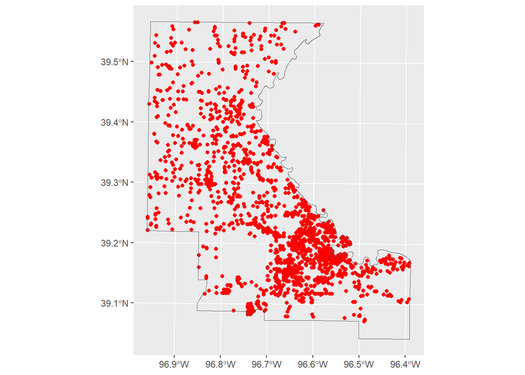

```r
#selecting onmly points that fall within riloey county
gw_rc <- gw_sf[r_county, ]

# Plotting the gw wells in riley county
ggplot() +
  geom_sf(data = gw_rc, color = "red") +
  geom_sf(data = r_county, fill = NA)
```

### Question 1

```r
#create ppp

gww_ppp <- as.ppp(gw_rc %>%
                    dplyr::select(c(WELL_USE, WELL_DEPTH, EST_YIELD)))
head(gww_ppp)
```

```
## Marked planar point pattern: 6 points
## marks are of storage type  'character'
## window: rectangle = [-82139.23, -33498.25] x [176316.34, 231867.79] units
```

```r
head(gww_ppp$marks)
```

```
## [1] "Domestic"                      "Pond/Swimming Pool/Recreation"
## [3] "Domestic"                      "Domestic"
## [5] "Domestic"                      "Domestic"
```

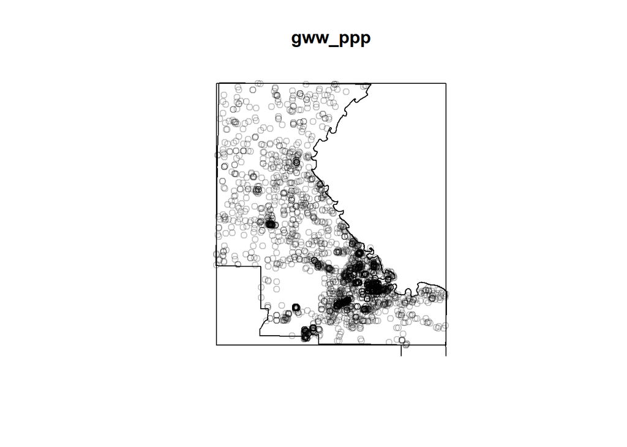

```r
plot(gww_ppp, use.marks = FALSE)
plot(r_county, color = NA, add = TRUE)
```

### Question 2

I removed duplicate groundwater well points using the unique and distinct function and replotted the point locations.

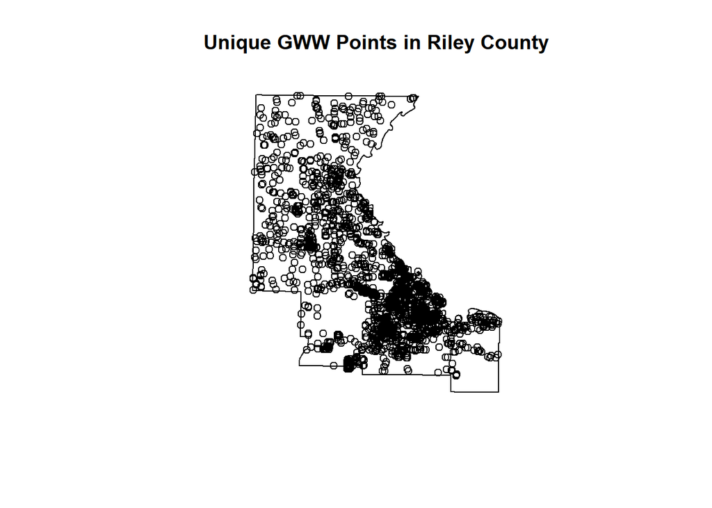

```r
gw_rc_unique <- unique(gw_rc)

gww_unique <- distinct(gw_rc_unique, geometry,
                       .keep_all = TRUE, na.rm = T)

gww_ppp_unique <- as.ppp(gww_unique)

marks(gww_ppp_unique) <- gww_unique[c("WELL_USE", "WELL_DEPTH", "EST_YIELD")]

#glimpse(gww_unique)

#Plot
plot(st_geometry(r_county), color = NA, main = "Unique GWW Points in Riley County")
plot(gww_ppp_unique, col = "black", use.marks = FALSE, add = TRUE)
box(which = "plot",lty = "blank")
```

### Question 3

I then created 3 plots of of the ppp object using one mark to display differences across points in each plot.

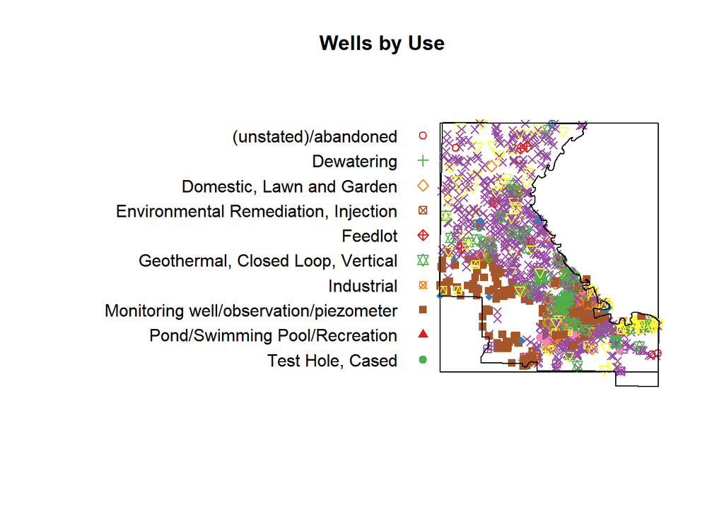

```r
# Set up color schemes for different types of marks
color_depth <- terrain.colors(100)  # For WELL_DEPTH
color_yield <- heat.colors(100)     # For EST_YIELD

# Define the range of WELL_DEPTH and EST_YIELD for color mapping
depth_range <- range(gww_ppp_unique$marks$WELL_DEPTH, na.rm = TRUE)
yield_range <- range(gww_ppp_unique$marks$EST_YIELD, na.rm = TRUE)


# Plot for WELL_USE
plot(gww_ppp_unique, which.marks = "WELL_USE", main = "Wells by Use", cols = brewer.pal(8, "Set1"))
plot(r_county, color = NA, add = TRUE)
```

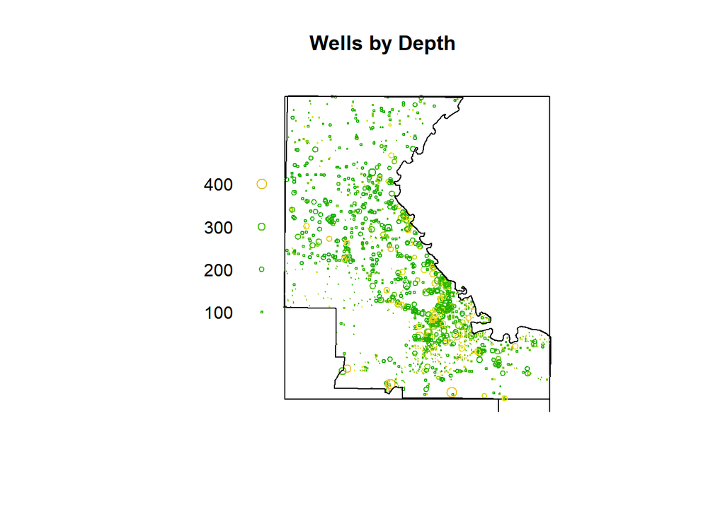

```r
# Plot for WELL_DEPTH
plot(gww_ppp_unique, which.marks = "WELL_DEPTH", main = "Wells by Depth",
     cols = color_depth[cut(gww_ppp_unique$marks$WELL_DEPTH, breaks = 100, labels = FALSE)],
     legend = TRUE)
plot(r_county, color = NA, add = TRUE)
```

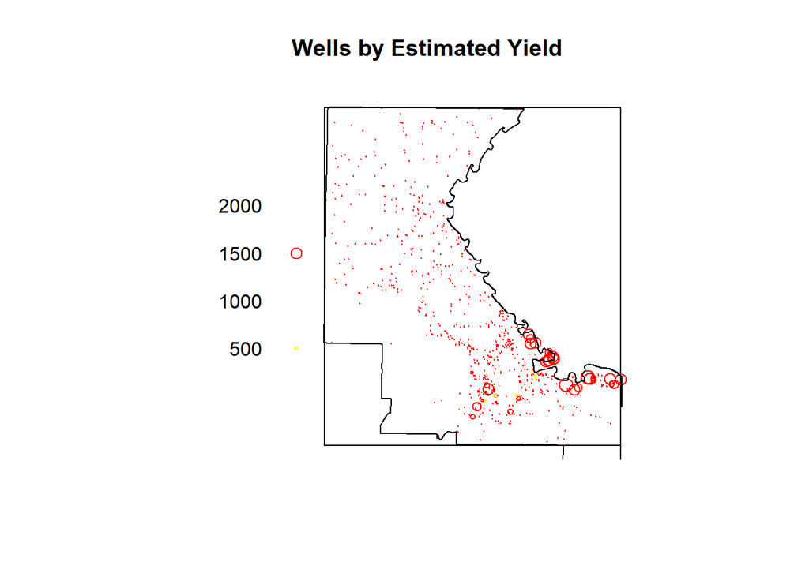

```r
# Plot for EST_YIELD
plot(gww_ppp_unique, which.marks = "EST_YIELD", main = "Wells by Estimated Yield",
     cols = color_yield[cut(gww_ppp_unique$marks$EST_YIELD, breaks = 100, labels = FALSE)],
     legend = TRUE)
plot(r_county, color = NA, add = TRUE)
```

### Question 4

I computed the mean center of the groundwater well points then plotted this point with the other groundwater well points, differentiating the mean center point with a red star and drawing a circle showing the standard distance from the mean center.

```r
#get the coordinates of the groundwater well dataset
xy <- st_coordinates(gww_unique)
head(xy) #x coordinate in column 1 and y coordinate in column 2
```

```
##              X        Y
## [1,] -80789.77 217889.2
## [2,] -54065.33 188892.7
## [3,] -80523.40 229462.2
## [4,] -80151.15 227409.2
## [5,] -80798.23 225585.9
## [6,] -69656.77 230999.4
```

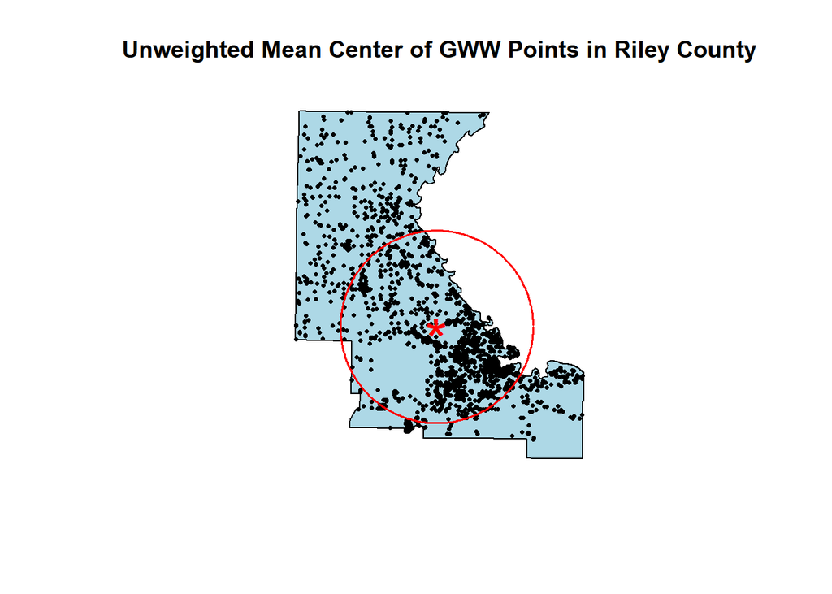

```r
# mean center
mc <- apply(xy, 2, mean) #apply the function `mean()` over columns

# standard distance
sd <- sqrt(sum((xy[,1] - mc[1])^2 + (xy[,2] - mc[2])^2) / nrow(xy)) #sum of squared differences between x coord and mean center x coord and y coord and mean center y coord divided by the number of records

# make a circle using the standard distance
bearing <- 1:360 * pi/180
cx <- mc[1] + sd * cos(bearing)
cy <- mc[2] + sd * sin(bearing)
circle <- cbind(cx, cy)

#Plotting
plot(st_geometry(r_county), col='light blue', main = "Unweighted Mean Center of GWW Points in Riley County")
plot(st_geometry(gww_unique), cex=.5, col = "black", pch =16, add = T)
points(cbind(mc[1], mc[2]), pch='*', col='red', cex=3, add = T)
lines(circle, col='red', lwd=1.5, add = T)
```

### Question 5

I created a weighted mean center by taking the weighted average of the x and y coordinates. I then Calculated the weighted mean center of the groundwater wells using EST_YIELD as a weighting factor and repeated the same for WELL_DEPTH. I plotted these points with the groundwater well points and the unweighted mean center.

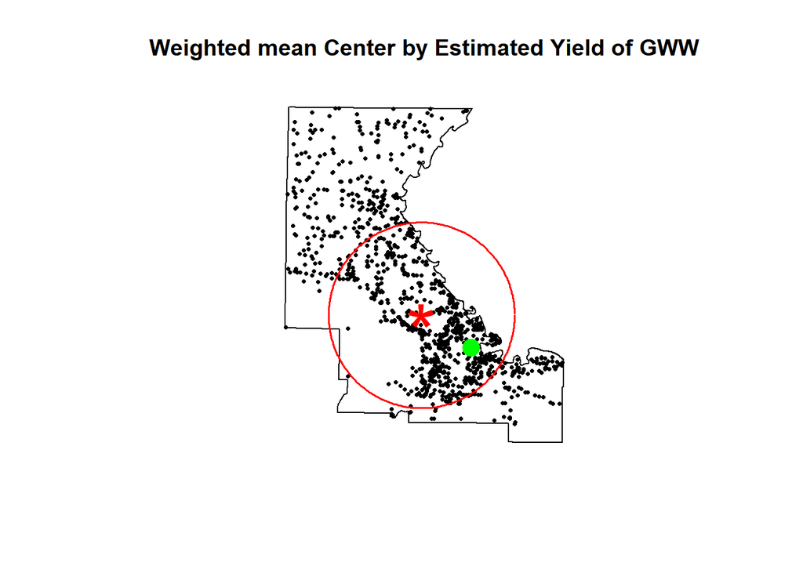

```r
# Remove NA values from EST_YIELD and WELL_DEPTH
gww_unique <- na.omit(gww_unique[, c("EST_YIELD", "WELL_DEPTH")])

# Calculate the weighted mean center using EST_YIELD as a weighting factor
weight_mean_x <- sum(st_coordinates(gww_unique)[, 1] * gww_unique$EST_YIELD) / sum(gww_unique$EST_YIELD)
weight_mean_y <- sum(st_coordinates(gww_unique)[, 2] * gww_unique$EST_YIELD) / sum(gww_unique$EST_YIELD)

weighted_mc_yield <- data.frame(X = weight_mean_x, Y = weight_mean_y)

# Plotting weighted mean center by est_yield
plot(st_geometry(r_county), col=NA, border = "black", main = "Weighted mean Center by Estimated Yield of GWW")
points(st_coordinates(gww_unique)[,1], st_coordinates(gww_unique)[,2], col = "black", pch = 16, cex = .5, add = TRUE) # Plot groundwater well points
points(cbind(mc[1], mc[2]), pch='*', col='red', cex=4, add = TRUE)  # Unweighted mean center
points(weighted_mc_yield$X, weighted_mc_yield$Y, pch= 20, col='green', cex=3, add = TRUE) # Weighted mean center using EST_YIELD
lines(circle, col='red', lwd=1.5, add = T)
```

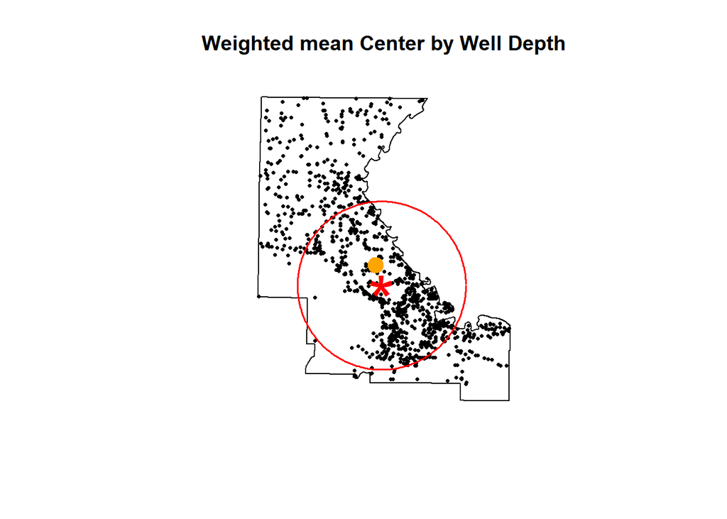

```r
# Calculate the weighted mean center using EST_DEPTH as a weighting factor

weight_mean_x1 <- sum(st_coordinates(gww_unique)[, 1] * gww_unique$WELL_DEPTH) / sum(gww_unique$WELL_DEPTH)
weight_mean_y1 <- sum(st_coordinates(gww_unique)[, 2] * gww_unique$WELL_DEPTH) / sum(gww_unique$WELL_DEPTH)

weighted_mc_depth <- data.frame(X = weight_mean_x1, Y = weight_mean_y1)


# Plotting weighted mean center by well_depth
plot(st_geometry(r_county), col=NA, border = "black", main = "Weighted mean Center by Well Depth")
points(st_coordinates(gww_unique)[,1], st_coordinates(gww_unique)[,2], col = "black", pch = 16, cex = .5, add = TRUE) # Plot groundwater well points
points(cbind(mc[1], mc[2]), pch='*', col='red', cex=4, add = TRUE)  # Unweighted mean center
points(weighted_mc_depth$X, weighted_mc_depth$Y, pch= 20, col='orange', cex=3, add = TRUE) # Weighted mean center using EST_DEPTH
lines(circle, col='red', lwd=1.5, add = T)
```

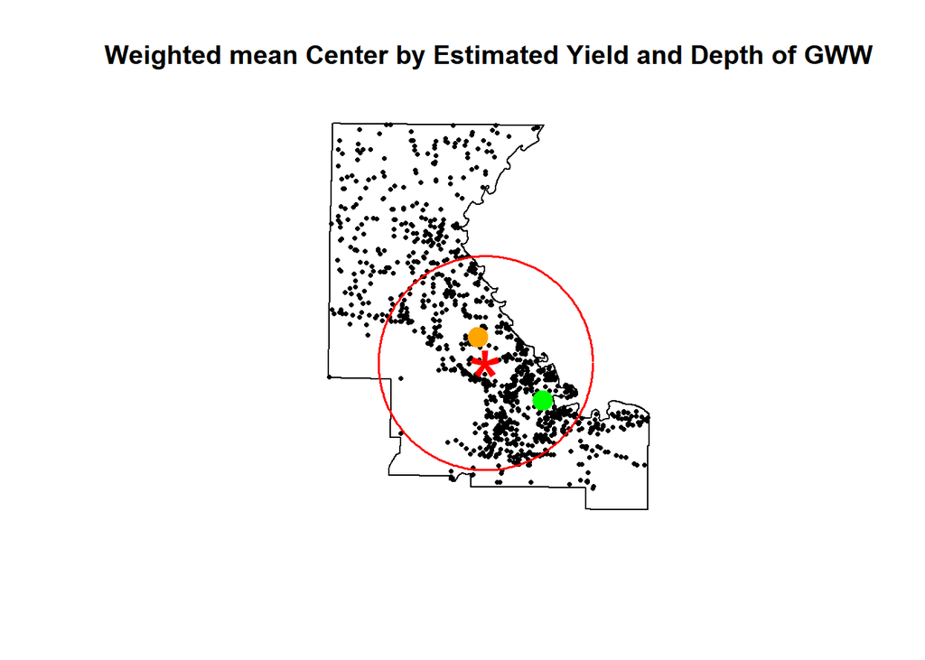

```r
# Plotting all weighted and unweighted points
plot(st_geometry(r_county), col=NA, border = "black", main = "Weighted mean Center by Estimated Yield and Depth of GWW")
points(st_coordinates(gww_unique)[,1], st_coordinates(gww_unique)[,2], col = "black", pch = 16, cex = .5, add = TRUE) # Plot groundwater well points
points(cbind(mc[1], mc[2]), pch='*', col='red', cex=4, add = TRUE)  # Unweighted mean center
points(weighted_mc_yield$X, weighted_mc_yield$Y, pch= 20, col='green', cex=3, add = TRUE) # Weighted mean center using EST_YIELD
points(weighted_mc_depth$X, weighted_mc_depth$Y, pch= 20, col='orange', cex=3, add = TRUE) # Weighted mean center using EST_DEPTH
lines(circle, col='red', lwd=1.5, add = T)
```

The shifts in the weighted mean center location of groundwater wells in Riley County when considering factors like EST_YIELD and WELL_DEPTH, can be as a result of landuse and agricultural practices. Riley County is predominantly agricultural, practices such as irrigation and crop type can impact groundwater yield and depth. Areas predominantly used for agricultural activities might have wells with greater yields to meet irrigation demands, leading to shifts in the weighted mean center when considering EST_YIELD.

Urban areas can also affect where wells are drilled and how deep they need to go to access sufficient water, influencing shifts in the weighted mean center considering WELL_DEPTH.

### Question 6

I computed the point density by quadrants, specifying 100 quadrants and plotted the quadrants together with the groundwater well points. I then computed the intensity (density) of points in each quadrant. I created a spatstat image object and plotted the density by quadrants with the groundwater well points.

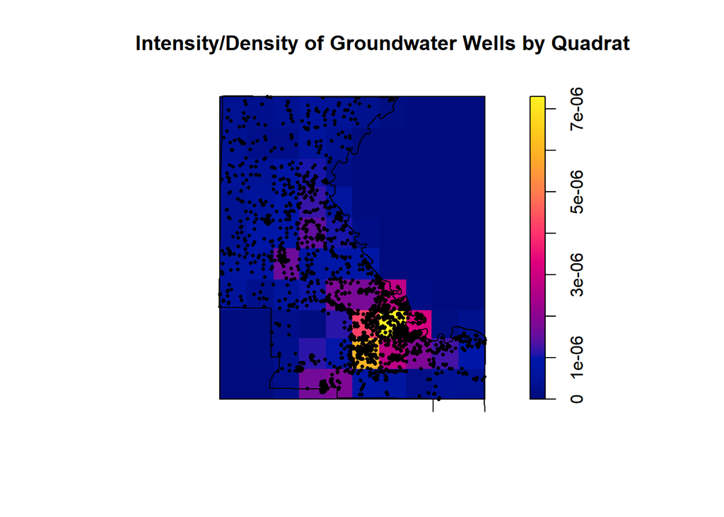

```r
gww_quad <- quadratcount(gww_ppp_unique, nx = 10, ny = 10)



## Intensity

gww_quad_int <- intensity(gww_quad, image = TRUE)

plot(gww_quad_int, main = "Intensity/Density of Groundwater Wells by Quadrat")
plot(gww_ppp_unique, pch = 16, cols = "black", cex = 0.5, add = TRUE)
plot(r_county, color = NA, add = TRUE)
```

### Question 7

I created a kernel density plot for the groundwater well locations and added the groundwater well points to the plot.

```r
gww_kd <- density(gww_ppp_unique)
gww_kd
```

```
## real-valued pixel image
## 128 x 128 pixel array (ny, nx)
## enclosing rectangle: [-82139, -33498] x [176320, 231870] units
```

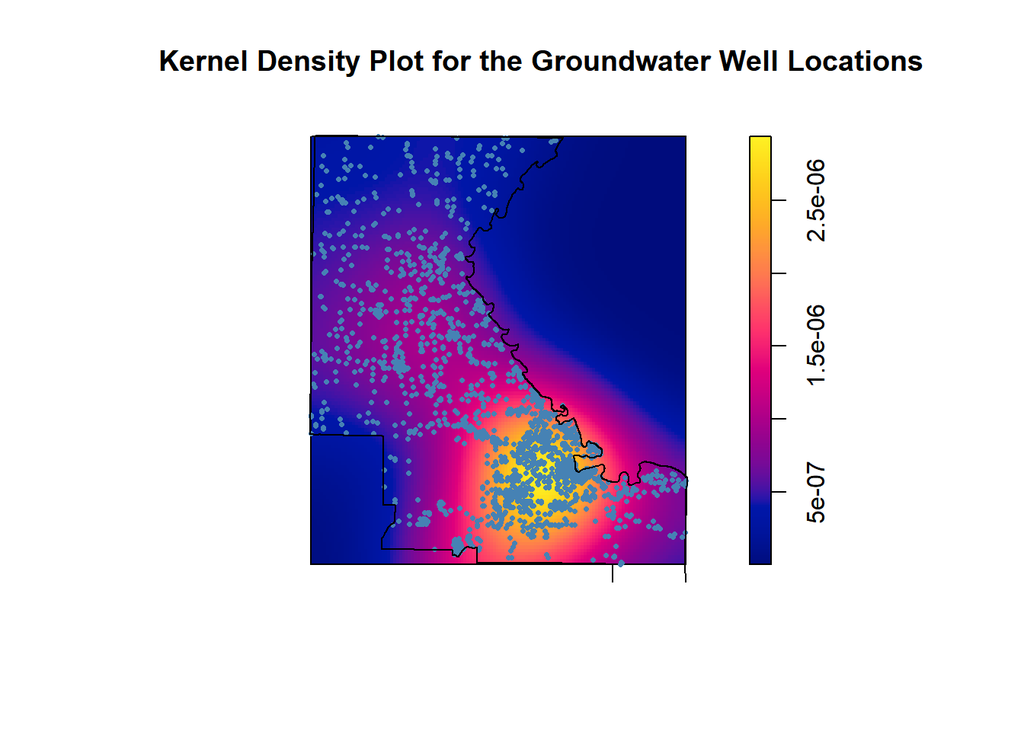

```r
plot(gww_kd, main = "Kernel Density Plot for the Groundwater Well Locations")
plot(gww_ppp_unique, pch = 16, cols = "steelblue", cex = 0.5, add = TRUE)
plot(r_county, color = NA, add = TRUE)
```

### Question 8

I read in the elevation raster, set the crs of the elevation raster and the transformed the crs of Riley county to that of the elevation layer. I then clipped of Riley county from the elevation data. I broke this into four categories and converted it into a spatstat compatible image format using as.im.RasterLayer1() function provided. I went ahead to tesselate this image and then plotted the tesselation together with the groundwater well points.

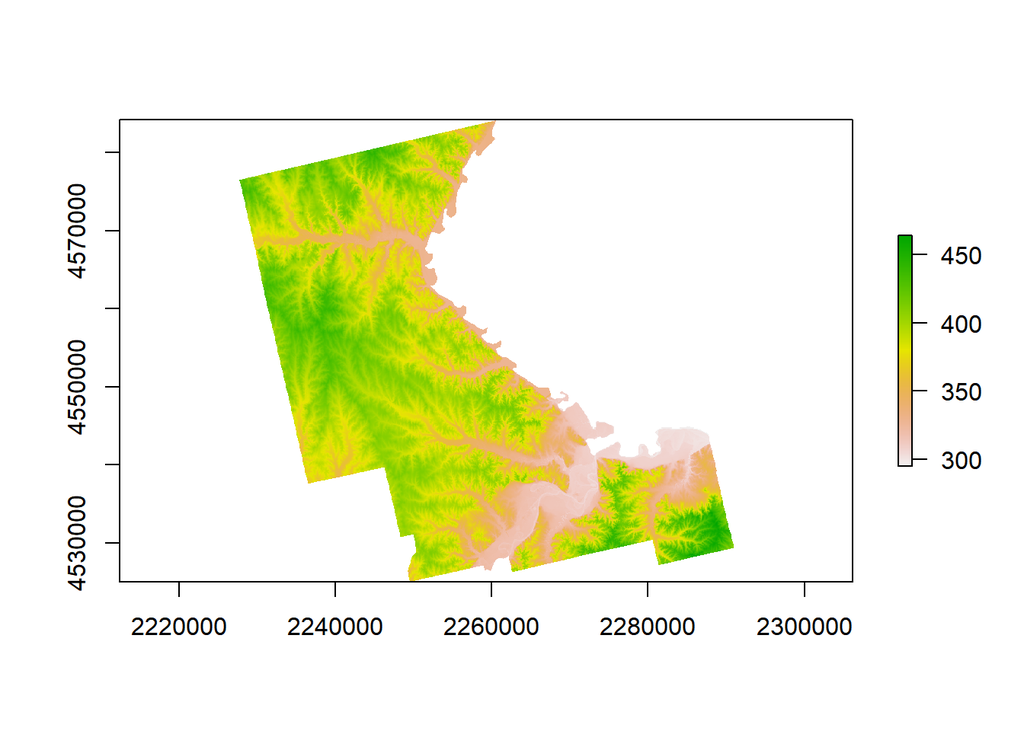

```r
elev <- raster("elevation.tif")
crs <- '+proj=utm +zone=11 +ellps=GRS80 +datum=NAD83 +units=m +no_defs'
elev <- projectRaster(elev, crs = crs, method = "bilinear")

r_county1 <- st_transform(r_county, crs = crs)

# Clipping out RC
elev_rc <- crop(elev, r_county1)
elev_rc <- mask(elev_rc, mask = r_county1)
plot(elev_rc)
```

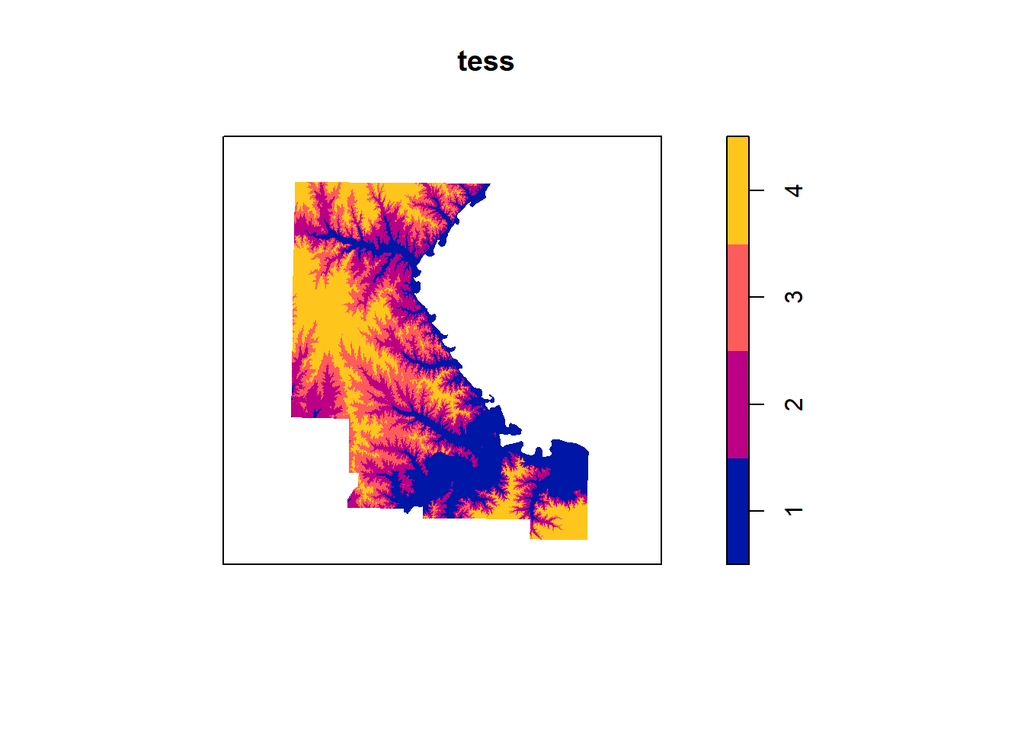

```r
#Projecting Raster

elev_rc <- projectRaster(elev_rc, crs = crs(r_county))

# Break it into four categories by quantiles
elev_cat <- cut(elev_rc, breaks = quantile(elev_rc, probs = seq(0, 1, by = 0.25)), include.lowest = TRUE)



#Calling in custom function
as.im.RasterLayer1 <- function(X) {
    X <- X[[1]]
    rs <- raster::res(X)
    e <- as.vector(raster::extent(X))
    out <- list(
        v = as.matrix(X, wide=TRUE)[nrow(X):1, ],
        dim = dim(X)[1:2],
        xrange = e[1:2],
        yrange = e[3:4],
        xstep = rs[1],
        ystep = rs[2],
        xcol = e[1] + (1:ncol(X)) * rs[1] + 0.5 * rs[1],
        yrow = e[4] - (nrow(X):1) * rs[2] + 0.5 * rs[2],
        type = "real",
        units  = list(singular="metre", plural="metre", multiplier=1) # replace "meters" with the actual units of your raster data
    )
    attr(out$units, "class") <- "unitname"
    attr(out, "class") <- "im"
    out
}


# Convert it to a spatstat compatible image format
im <- as.im.RasterLayer1(elev_cat)

# Tessellate this image
tess <- tess(image = im)
plot(tess)
```

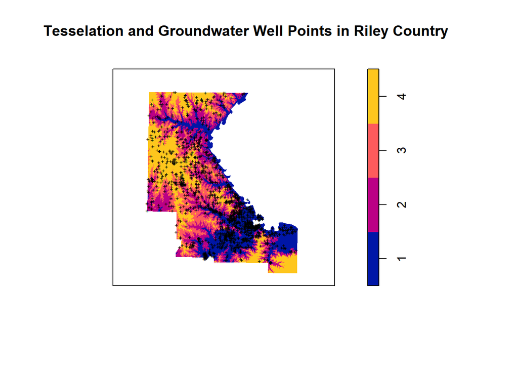

```r
# Plot the tessellation together with the groundwater well points
plot(tess, main = "Tesselation and Groundwater Well Points in Riley Country")
plot(gww_ppp_unique, pch = "+", cols = "black", cex = 0.5, add = TRUE)
```

### Question 9

Finally, I calculated the quadrant counts by tesselation area (elevation range) and plotted the intensity of groundwater well points across these areas.

```r
# Calculate quadrat counts by tessellation area (elevation range)
quad_tess <- quadratcount(gww_ppp_unique, tess = tess)
quad_tess
```

```
## tile
##    1    2    3    4
## 1004  375  280  195
```

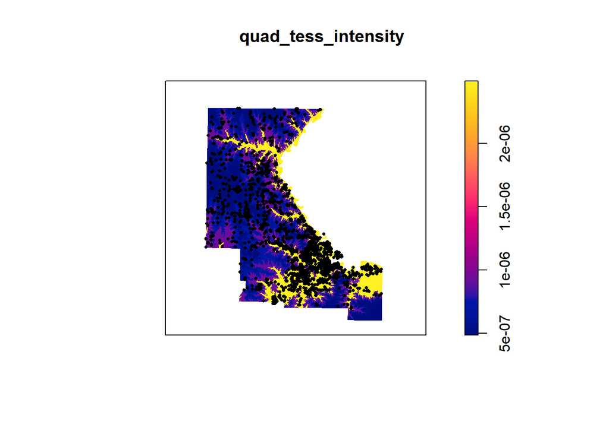

```r
quad_tess_intensity <- intensity(quad_tess, image = T)
plot(quad_tess_intensity)


# # Calculate the intensity of groundwater well points across these areas
# gww_intensity <- rhohat(gww_ppp_unique, im)
#
#
# # Plot the intensity
# plot(rhohat(gww_ppp_unique, gww_intensity), main="Intensity of Groundwater Well Points Across Elevation Ranges")

plot(quad_tess_intensity)
points(gww_ppp_unique, pch = 16, cex = .5, add = T)
```